# LSI36001 Clinical Data Mining Exercise Set 3

EXERCISE 3

1. OBESITY PARADOX

Packages and data loading:

```r
library("impute")
library("ggplot2")
library("Biobase")
library("curatedBreastData")
library("stringr")
library("dplyr")
library("tidyr")
library(RColorBrewer)

#load up master clinical data table
data("clinicalData")
# converting clinical data to data frames
```

```r
CD <- data.frame(clinicalData$clinicalTable)
var<- data.frame(clinicalData$clinicalVarDef)
```

Reading the BMI-data

```r
BMI<- read.csv(file = "breast_cancer_clindata_BMI.csv")
```

The data seems off, it seems that the unique ID and BMI are in the same cell.

Let’s fix that:

```r
BMI_df <- BMI %>%
  separate(dbUniquePatientID.BMI,
           sep = "\t",
           c('dbUniquePatientID','BMI'))
```

Merging the two data frames:

```r
df <- BMI_df %>%
  mutate_if(is.character, as.double) %>%
  inner_join(CD, by = c('dbUniquePatientID'))
```

RFS = relapse free survival, RFS_months_or_MIN_months_of_RFS  
Months until RFS or minimum months of RFS

Linear regression with RFS and BMI:

```r
summary(fit)
```

```
Call:
lm(formula = y_RFS ~ x_BMI, data = df)

Residuals:
    Min      1Q  Median      3Q     Max
-71.783 -30.159  -5.048  30.227 126.168

Coefficients:
            Estimate Std. Error t value Pr(>|t|)
(Intercept)  23.4726    20.8535   1.126   0.2606
x_BMI         1.7503     0.7425   2.357   0.0186 *
---
Signif. codes:  0 ‘***’ 0.001 ‘**’ 0.01 ‘*’ 0.05 ‘.’ 0.1 ‘ ’ 1

Residual standard error: 40.57 on 968 degrees of freedom
  (1749 observations deleted due to missingness)
Multiple R-squared:  0.005708,  Adjusted R-squared:  0.004681
F-statistic: 5.557 on 1 and 968 DF,  p-value: 0.0186
```

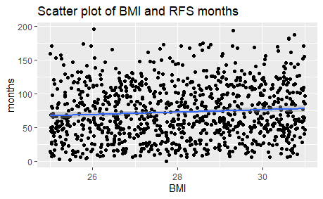

```r
ggplot(df, aes(x_BMI, y_RFS))+
  geom_point() +
  geom_smooth(method = 'lm') +
  ggtitle("Scatter plot of BMI and RFS months") +
  ylab("months") +
  xlab("BMI")
```

```r
cor(corr_table$BMI , corr_table$RFS_months_or_MIN_months_of_RFS, method = "pearson")
```

```
[1] 0.07555107
```

Strength & direction of the association:

After using Pearson correlation test for the data, it seems that the correlation/association is small 0.07 and positive.

I would say that the data doesn’t look linear according to the plot, however the p-value in F-test of the linear fit is below <0.05 meaning that the x is indeed related to y in some way. Also the true RFS can deviate from the true regression line by 40.57 (Residual error) which sounds very high. The R^2 is very low meaning the x doesn’t explain the variance in the response variable well. 0.005708 would mean roughly 0.5708 % of the variance is explained by the x (BMI). I would then state that Napoleon is wrong over all.

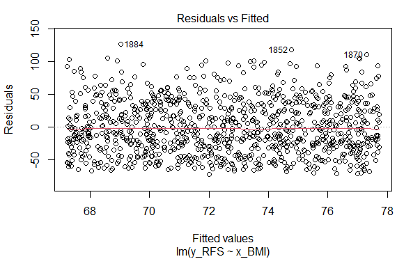

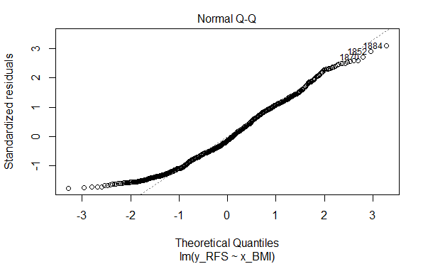

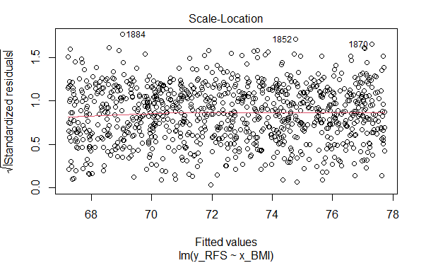

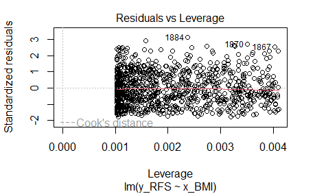

1. Residuals vs Fitted

   This plots checks the linear relationship assumption. How the residuals are scattered.  
   Residuals are on the y-axis and the fitted values appear on the x-axis
2. Normal QQ-plot  
   This plot shows are the residuals normally distributed.
3. Scale location

   This plot shows if residuals are spread equally along the ranges of predictors, and with this plot we can check the homoscedasticity.
4. Residuals vs Leverage  
   This plot is created to find out influential values if they are in the data.

   Leverage refers to the extent to which the coefficients in the regression line would change if one observation was dropped out of the data.  
   Standardized residuals refer to the standardized difference between a predicted value and the observed value.

   So it inform about the outliers of the data. Cook’s distance is used to define the interesting values. Outside the distance lies the values that are significant.

Based on the plots, comment on

1. the relationship between these variables:  
   This can be seen in the Residuals vs Fitted plot which shows that our variables have linear relationship, since there is no visible pattern in the plot and the line is horizontal.
2. distribution of the residuals  
   The distribution of residuals is assumed to me normal. This is true in our case and it can be seen in the QQ-plot since the values follow the line with some exceptions on both ends, more on the lower tail of the dots.
3. homogeneity of variance of the residuals:  
   In our data from the Scale location plot we can see that the line is horizontal and the dots (residual) are spreading with some outliers. Residuals are then homogenic by their variance.
4. extreme values that might influence regression results.  
   In our data it seems that the Cook’s distance (in the Residuals vs Leverage plot) is outside of the plot so meaning we don’t have any significant outliers. The plot has highlighted some values 1884, 1870 and 1867 but they are not statistically significant because they are not outside of the Cook’s distance.

   How well does the linear regression model work for these data?  
   According to the plot it seems that it doesn’t fit or moreover the data points are so spread that they do not follow the line. Meaning that they deviate from it quite well
3. WHAT IS OBESITY PARADOX:  
   According to Lennon et al. 2016 obesity paradox means that some studies have shown that excess weight is associated with reduced cancer survival and other studies have shown that overweight are associated with improved survival.

   Confounding is defined so that when there are variables accosiated with both the outcome and the defining.

   Confounding parameters in the BMI and RFS could be smoking, physical activity. In their article Lennot et al. gives one example from Hakimi et al. 2013 paper where higher BMI was associated with reduced mortality (cancer specific) in univariate analysis, but the association was lost when they added stage and grade variables to the analysis.

Lennon, H., Sperrin, M., Badrick, E., & Renehan, A. G. (2016). The Obesity Paradox in Cancer: a Review. In Current Oncology Reports (Vol. 18, Issue 9). Springer Science and Business Media LLC. https://doi.org/10.1007/s11912-016-0539-4 (https://www.ncbi.nlm.nih.gov/pmc/articles/PMC4967417/pdf/11912_2016_Article_539.pdf)

```r
hormone <- subset(df, df$hormone_therapyClass == 1) %>%
  select(BMI,
         hormone_therapyClass,
         RFS_months_or_MIN_months_of_RFS) %>%
  subset(!is.na(RFS_months_or_MIN_months_of_RFS))

no_hormone <- subset(df, df$hormone_therapyClass == 0) %>%
  select(BMI,
         hormone_therapyClass,
         RFS_months_or_MIN_months_of_RFS) %>%
  subset(!is.na(RFS_months_or_MIN_months_of_RFS))
```

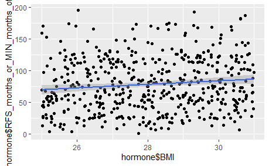

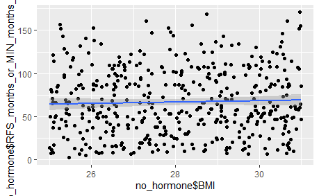

Linear regression on the two groups

```r
#group with hormone (hormone_therapyClass = 1)
h_fit <-lm(hormone$RFS_months_or_MIN_months_of_RFS~hormone$BMI,
           data = hormone)
```

```r
#group without hormone (hormone_therapyClass = 0)
noh_fit <- lm(no_hormone$RFS_months_or_MIN_months_of_RFS~no_hormone$BMI,
              data = no_hormone)
#plot(noh_fit)
```

```r
check_model()
```

[output not shown]

Results:

```r
#summary(h_fit)
summary(noh_fit)
```

```
Call:
lm(formula = no_hormone$RFS_months_or_MIN_months_of_RFS ~ no_hormone$BMI,
    data = no_hormone)

Residuals:
    Min      1Q  Median      3Q     Max
-62.530 -28.229  -6.631  29.524 102.111

Coefficients:
               Estimate Std. Error t value Pr(>|t|)
(Intercept)     44.3494    28.3047   1.567    0.118
no_hormone$BMI   0.7925     1.0072   0.787    0.432

Residual standard error: 38.35 on 454 degrees of freedom
Multiple R-squared:  0.001362,  Adjusted R-squared:  -0.000838
F-statistic: 0.619 on 1 and 454 DF,  p-value: 0.4318
```

e.

```r
x1 <- hormone$BMI
y1 <- hormone$RFS_months_or_MIN_months_of_RFS

x2 <- no_hormone$BMI
y2 <- no_hormone$RFS_months_or_MIN_months_of_RFS

df <- subset(df, !is.na(df$hormone_therapyClass) &
               !is.na(df$RFS_months_or_MIN_months_of_RFS) &
               !is.na(df$BMI))
x <- df$BMI
y <- df$RFS_months_or_MIN_months_of_RFS

res<-ggplot(df, aes(x =df$BMI,
               y = df$RFS_months_or_MIN_months_of_RFS,
               color = hormone_therapyClass)) +
  geom_point() +
  geom_smooth(method = 'lm') +
  #geom_smooth(aes(x,y,color=df$hormone_therapyClass),method = 'lm') +
  #geom_smooth(aes(x1,y1),method = 'lm', ) +
  ggtitle("Scatter plot: RFS vs BMI In two groups of patients",
          subtitle ="breast cancer curated dataset") +
  ylab("RFS, months") +
  xlab("Body-mass Index") +
  theme(legend.position = "bottom",
        legend.title = "hormone_Theray_Class") +
  theme_classic()
res <- res + theme(legend.position = "bottom")
res_plot<-res + scale_color_brewer(palette = "Accent")
res_plot
```

[output not shown]

Saving the plot as png file:

```r
png(file = "plot.png",
    width = 300,
    height = 300)
res_plot
dev.off()
```

2. STEPWISE LOGISTIC REGRESSION
1. Define response variable and predictors

response variable would be the presence of metastasis which is a categorical variable found in the clinical data as ‘metastasis’ with values 1 = yes and 0 = no

predictors would be the ones Napoleon selected: age, tumor size pre treatment and pre surgery. Also HER2 (Pre-treatment HER2 IHC status (1=YES, positive, 0=NO.) and menopausal status.

Because the target variable is binary, we want to use binary logistic regression but since there are many predictors we use multiple logistic regression.

p_y= Odds ratio, which means probability of presence divided by probability of absence

2. regression by iterating:

```r
df <- CD %>%
  select(metastasis,
         age,
         tumor_size_cm_preTrt_preSurgery,
         HER2_preTrt,
         menopausal_status) #%>%
#  filter(!is.na(metastasis) &
#           !is.na(age) &
#           !is.na(tumor_size_cm_preTrt_preSurgery) &
#           !is.na(HER2_preTrt) & !is.na(menopausal_status) )
```

1. logistic regression

```r
summary(fit1)
```

```
Call:
glm(formula = metastasis ~ age, family = binomial, data = df)

Deviance Residuals:
    Min       1Q   Median       3Q      Max
-0.8419  -0.6222  -0.5406  -0.4746   2.2938

Coefficients:
             Estimate Std. Error z value Pr(>|z|)
(Intercept) -3.187142   0.537833  -5.926 3.11e-09 ***
age          0.025242   0.008696   2.903   0.0037 **
---
Signif. codes:
0 ‘***’ 0.001 ‘**’ 0.01 ‘*’ 0.05 ‘.’ 0.1 ‘ ’ 1

(Dispersion parameter for binomial family taken to be 1)

    Null deviance: 556.11  on 643  degrees of freedom
Residual deviance: 547.47  on 642  degrees of freedom
AIC: 551.47

Number of Fisher Scoring iterations: 4
```

#can’t HER and menopausal

```r
df$menopausal_status <- ifelse(df$menopausal_status == "post", 1, 0)
```

```r
#fit two with age and tumor size

df = df[!is.na(df$metastasis),]
metastasis <- df$metastasis
age <- df$age
tumor_size <- df$tumor_size_cm_preTrt_preSurgery
glm(metastasis~age + tumor_size,
            data = df,
            family = binomial) %>%
  summary()
```

[output not shown]

```r
#fit three with age and tumor size

df = df[!is.na(df$metastasis),]
metastasis <- df$metastasis
age <- df$age
tumor_size <- df$tumor_size_cm_preTrt_preSurgery
HER2_status <- df$HER2_preTrt
glm(metastasis~age + tumor_size + HER2_status,
            data = df,
            family = binomial) %>%
  summary()
```

[output not shown]

```r
df = df[!is.na(df$metastasis),]
metastasis <- df$metastasis
menopausal_stat <- df$menopausal_status
tumor_size <- df$tumor_size_cm_preTrt_preSurgery
HER2_status <- df$HER2_preTrt
df$menopausal_status <- as.integer(df$menopausal_status)


glm(metastasis~tumor_size + menopausal_stat,
            data = df,
            family = binomial) %>%
  summary()
```

[output not shown]